# Homework 04 — Lasso and Variable Selection

Simulation, coordinate descent, and diabetes prediction

All numerical results below were computed in Python. The original assignment, course-provided solution, and data are preserved alongside this report. Frequencies are proportions, so 0.520 means selection in 52% of the 200 repetitions. The full analysis code is included in the appendix. This report was prepared with AI assistance.

## Question 1: Signal strength and correlated substitutes

### Simulation and fitting conventions

I used NumPy’s `default_rng(43246)`. In each repetition I drew $X_1$, $Z$, the eight remaining covariate vectors, and the noise vector, in that order, exactly following the question’s generating equation. For every generated dataset I fitted all four penalties before generating the next dataset. Each column was transformed using

$$z_{ij}=\frac{x_{ij}-\bar x_j}{s_j},\qquad
s_j^2=\frac1n\sum_i(x_{ij}-\bar x_j)^2.$$

The centered response was fitted with `Lasso(alpha=lam, fit_intercept=False, tol=1e-10, max_iter=100000)`. In scikit-learn, `alpha` specifies $\lambda$; `Lasso` does not automatically standardize columns. I therefore standardized them explicitly before fitting. Setting `fit_intercept=False` here is appropriate because the intercept has already been fitted separately as $\bar y$; it is not penalized. The objective on the standardized design is

$$\frac{1}{2n}\|\widetilde y-Zb\|_2^2+\lambda\|b\|_1.$$

I stored original-scale slopes $\widehat\beta_j=b_j/s_j$ in an array of shape $(200,10,4)$. The corresponding original-scale intercept is $\widehat\beta_0=\bar y-\sum_j\bar x_j\widehat\beta_j$. Selection means $|\widehat\beta_j|>10^{-8}$.

All **800 lasso fits converged** without a convergence warning. The largest iteration count was **11,153**, below the limit of 100,000; the maximum reported dual gap was $1.19\times10^{-11}$. Convergence warnings are treated as errors in the script rather than suppressed.

### (a) Selection frequencies and fitted magnitudes

**Selection frequency** at each penalty:

| Covariate | 0.08 | 0.12 | 0.18 | 0.24 |
| --- | --- | --- | --- | --- |
| X1 | 0.520 | 0.520 | 0.495 | 0.410 |
| X2 | 0.495 | 0.460 | 0.385 | 0.340 |
| X3 | 0.980 | 0.970 | 0.865 | 0.670 |
| X4 | 0.755 | 0.610 | 0.325 | 0.115 |
| X5 | 0.385 | 0.205 | 0.060 | 0.020 |
| X6 | 0.405 | 0.200 | 0.055 | 0.015 |
| X7 | 0.375 | 0.185 | 0.050 | 0.010 |
| X8 | 0.405 | 0.215 | 0.050 | 0.005 |
| X9 | 0.370 | 0.195 | 0.085 | 0.010 |
| X10 | 0.400 | 0.210 | 0.050 | 0.015 |

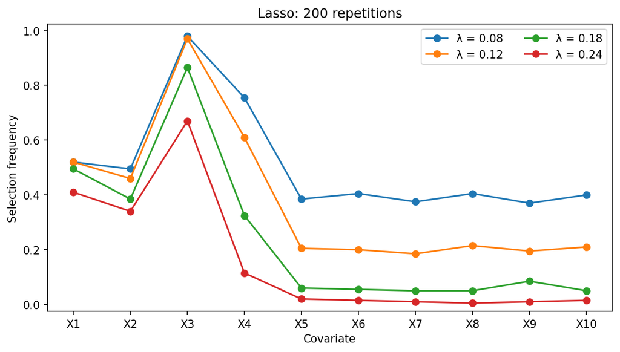

Lasso selection frequencies across 200 repetitions.

**Mean absolute original-scale slope**, including the fitted zeros:

| Covariate | 0.08 | 0.12 | 0.18 | 0.24 |
| --- | --- | --- | --- | --- |
| X1 | 0.115 | 0.097 | 0.068 | 0.040 |
| X2 | 0.101 | 0.080 | 0.054 | 0.034 |
| X3 | 0.211 | 0.172 | 0.118 | 0.072 |
| X4 | 0.071 | 0.043 | 0.016 | 0.004 |
| X5 | 0.022 | 0.010 | 0.003 | 0.001 |
| X6 | 0.022 | 0.010 | 0.002 | 0.000 |
| X7 | 0.020 | 0.009 | 0.002 | 0.001 |
| X8 | 0.020 | 0.008 | 0.001 | 0.000 |
| X9 | 0.023 | 0.012 | 0.003 | 0.000 |
| X10 | 0.021 | 0.009 | 0.002 | 0.000 |

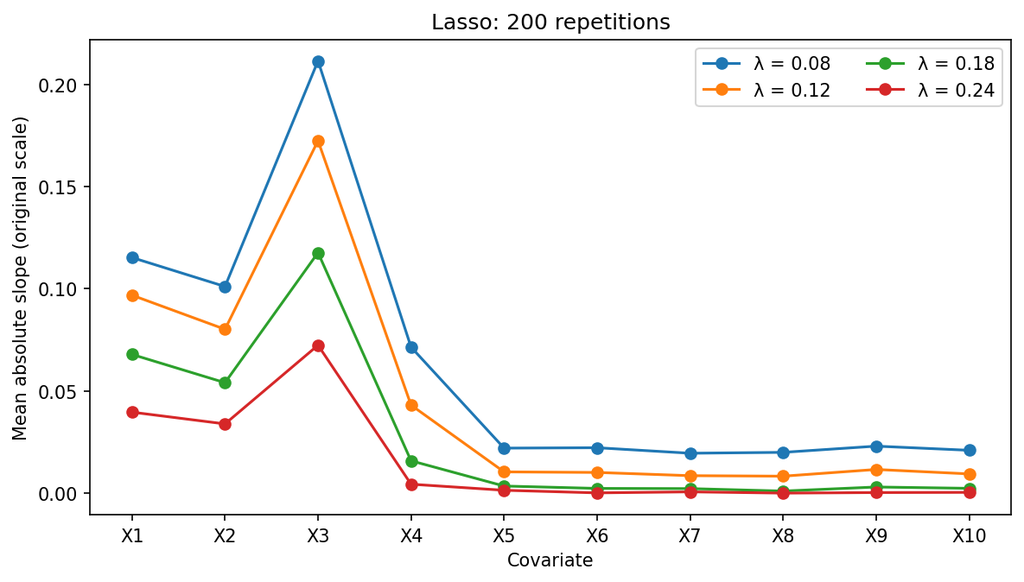

Lasso mean absolute fitted slopes, including zeros.

Increasing the penalty generally lowers both selection frequency and mean absolute slope. The independent stronger signal $X_3$ remains selected more often than $X_4$. Noise variables become rare as the penalty grows. The frequency for $X_1$ is unchanged between the first two penalties, illustrating that individual-variable selection need not decrease strictly along a lasso path, especially when predictors can substitute for one another. The general shrinkage trend concerns these observed summaries, not a guarantee of monotonicity for every individual coefficient.

### (b) Correlated-pair outcomes

| Penalty | Only X1 | Only X2 | Both | Neither |
| --- | --- | --- | --- | --- |
| 0.080 | 0.485 | 0.460 | 0.035 | 0.020 |
| 0.120 | 0.495 | 0.435 | 0.025 | 0.045 |
| 0.180 | 0.490 | 0.380 | 0.005 | 0.125 |
| 0.240 | 0.405 | 0.335 | 0.005 | 0.255 |

The marginal frequencies are similar in broad scale: for $X_1$ they are 0.520, 0.520, 0.495, and 0.410, while for $X_2$ they are 0.495, 0.460, 0.385, and 0.340. The predictors have symmetric population roles: the same variance, the same true coefficient, and almost identical information. The finite sample experiment need not give identical frequencies; for example, the gap is 0.110 at $\lambda=0.18$. Repetition-level sampling fluctuations and tiny differences in the observed scores decide which variable is retained.

Selecting exactly one member is overwhelmingly more common than selecting both. As $\lambda$ rises, selecting neither increases from 2.0% to 25.5%, while selecting both falls from 3.5% to 0.5%. Individual outcome probabilities are not all strictly monotone: the only-$X_1$ outcome first rises slightly and then declines.

To see why a generating coefficient can be omitted, imagine identical columns and two nonnegative coefficients with fixed sum $c$. Their predictions depend only on $c$, and their lasso penalty is $\lambda(|b_1|+|b_2|)=\lambda c$ regardless of how the sum is allocated. There is no penalty advantage to sharing the coefficient. With nearly identical columns, a small difference in fit can favor allocating the signal to just one member. Sparsity therefore need not recover every generating variable when signals are highly redundant.

### (c) Strong signals, weak signals, and noise

| Penalty | $X_3$ | $X_4$ | Mean among $X_5,\ldots,X_{10}$ |
| --- | --- | --- | --- |
| 0.08 | 0.980 | 0.755 | 0.390 |
| 0.12 | 0.970 | 0.610 | 0.202 |
| 0.18 | 0.865 | 0.325 | 0.058 |
| 0.24 | 0.670 | 0.115 | 0.013 |

The 0.30 signal in $X_3$ survives the threshold more often than the 0.15 signal in $X_4$. Increasing $\lambda$ screens out noise but also removes weak genuine signals; at 0.24, $X_4$ is retained in only 11.5% of runs. Random empirical associations can retain noise variables, especially at low penalties.

A fitted zero does not prove a zero population coefficient: $X_1$ and $X_2$ each have a nonzero generating coefficient yet either is frequently omitted. A selected coefficient does not prove unique importance either: the other member of this pair can provide almost the same predictive information. Selection is conditional on the data, penalty, and other available predictors.

## Question 2: Elastic net with an equal penalty mix

I reused the exact same 200 generated datasets as Question 1. This is equivalent to resetting the seed and repeating the same draw sequence, and ensures that differences reflect the fitting method rather than a new simulation. `ElasticNet(alpha=lam, l1_ratio=0.5, fit_intercept=False, tol=1e-10, max_iter=100000)` uses the objective

$$\frac{1}{2n}\|\widetilde y-Zb\|_2^2+
\lambda\left(0.5\|b\|_1+\frac{0.5}{2}\|b\|_2^2\right).$$

Thus Python’s `l1_ratio` is the question’s mixing parameter, while Python’s `alpha` is the overall penalty. Scaling and conversion back to original slopes match Question 1. All **800 elastic-net fits converged**; the maximum iteration count was 259 and the largest dual gap was $1.40\times10^{-11}$.

### (a) Selection frequencies

| Covariate | 0.08 | 0.12 | 0.18 | 0.24 |
| --- | --- | --- | --- | --- |
| X1 | 0.975 | 0.970 | 0.955 | 0.925 |
| X2 | 0.960 | 0.975 | 0.970 | 0.945 |
| X3 | 0.995 | 0.995 | 0.975 | 0.970 |
| X4 | 0.880 | 0.820 | 0.725 | 0.600 |
| X5 | 0.640 | 0.485 | 0.350 | 0.210 |
| X6 | 0.660 | 0.525 | 0.370 | 0.200 |
| X7 | 0.665 | 0.510 | 0.325 | 0.185 |
| X8 | 0.660 | 0.530 | 0.355 | 0.220 |
| X9 | 0.645 | 0.515 | 0.320 | 0.200 |
| X10 | 0.650 | 0.530 | 0.315 | 0.205 |

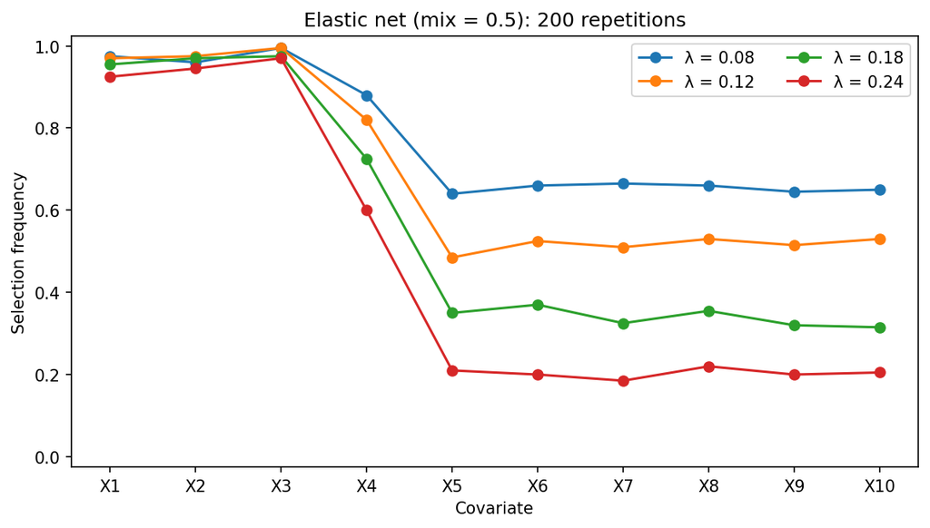

Elastic-net selection frequencies across the same 200 datasets.

Selection frequencies increase for every covariate at all four penalties relative to lasso. The most pronounced changes are for the correlated pair, particularly at the largest penalty: $X_1$ rises from 0.410 to 0.925 and $X_2$ from 0.340 to 0.945. The weaker independent signal also benefits: $X_4$ rises from 0.115 to 0.600 at that penalty. Noise selection increases as well, so greater retention is not by itself evidence of better variable recovery.

### (b) Correlated-pair outcomes and grouping

| Penalty | Only X1 | Only X2 | Both | Neither |
| --- | --- | --- | --- | --- |
| 0.080 | 0.035 | 0.020 | 0.940 | 0.005 |
| 0.120 | 0.010 | 0.015 | 0.960 | 0.015 |
| 0.180 | 0.010 | 0.025 | 0.945 | 0.020 |
| 0.240 | 0.005 | 0.025 | 0.920 | 0.050 |

Both members are now retained together in 92.0%–96.0% of repetitions, compared with only 0.5%–3.5% under lasso. This is strong joint retention, but it is not perfect selection in every dataset. At the largest penalty, 5% of runs omit both.

For identical columns and fixed coefficient sum $c$, the squared penalty is minimized by equal allocation:

$$b_1^2+b_2^2
=\frac{c^2}{2}+\frac{(b_1-b_2)^2}{2}\geq\frac{c^2}{2}.$$

The additional squared penalty therefore favors sharing signal between highly correlated columns. In standardized coordinate descent, elastic net updates a coefficient as $S(a_j,\lambda/2)/(1+\lambda/2)$; this shows both the weaker threshold and the additional smooth shrinkage.

### (c) Noise screening

| Penalty | Lasso: mean noise selection | Elastic net: mean noise selection | Elastic net: both pair members |
| --- | --- | --- | --- |
| 0.08 | 0.390 | 0.653 | 0.940 |
| 0.12 | 0.202 | 0.516 | 0.960 |
| 0.18 | 0.058 | 0.339 | 0.945 |
| 0.24 | 0.013 | 0.203 | 0.920 |

Noise selection still decreases as the penalty increases. At the same numerical $\lambda$, however, elastic net has an $\ell_1$ threshold of $\lambda/2$ rather than $\lambda$, so it screens less aggressively than lasso. At **0.18 and 0.24**, it usually retains both correlated predictors while excluding most noise variables: the mean excluded proportions are 66.1% and 79.7%, respectively. Here “most” means the average proportion of noise variables excluded, not that every repetition excludes every noise variable. At 0.12, fewer than half are excluded on average.

## Question 3: Coordinate descent and the lasso path

### (a) Implementation and convergence

I used `default_rng(43247)`, drew each of the three covariate vectors and then the noise vector, and standardized with divisor 100. The response was centered. Starting with zero slopes, I traversed the requested descending penalty grid and used the preceding solution as the next starting vector.

For coordinate $j$, the partial residual and update were

$$r_{-j}=\widetilde y-Zb+z_jb_j,\qquad
a_j=\frac{z_j^{\mathsf T}r_{-j}}{100},\qquad
b_j\leftarrow \operatorname{sign}(a_j)(|a_j|-\lambda)_+.$$

I updated coefficients immediately in cyclic order and stopped only after a full cycle had maximum coefficient change below $10^{-10}$. The appendix contains the complete hand-written loop; package fitting was used only as an independent check.

| lambda | X1 | X2 | X3 | cycles |
| --- | --- | --- | --- | --- |
| 2.500000 | 0.000000 | -0.000000 | 0.000000 | 1 |
| 2.000000 | 0.000000 | -0.000000 | 0.000000 | 1 |
| 1.500000 | 0.000000 | -0.125150 | 0.000000 | 2 |
| 1.000000 | 0.000000 | -0.625150 | 0.000000 | 2 |
| 0.600000 | 0.185593 | -1.030712 | 0.000000 | 5 |
| 0.400000 | 0.391772 | -1.236892 | 0.000000 | 5 |
| 0.250000 | 0.546407 | -1.391526 | 0.000000 | 5 |
| 0.150000 | 0.649497 | -1.494616 | 0.000000 | 5 |
| 0.080000 | 0.721660 | -1.566779 | 0.000000 | 5 |
| 0.030000 | 0.773204 | -1.618324 | -0.000000 | 5 |

All ten fits converged within five cycles. Coefficients are on the **standardized covariate scale**, and the separately fitted intercept is **1.285858**. The largest KKT residual was $7.99\times10^{-15}$, and every slope vector agreed with an independent scikit-learn lasso fit within absolute tolerance $10^{-8}$.

The initial score vector is approximately $(0.754702,-1.625150,0.262903)$, giving

$$\lambda_{\max}=\left\|\frac{Z^{\mathsf T}\widetilde y}{100}\right\|_\infty
=1.625150.$$

The slopes are all zero at 2.5 and 2.0, the two grid values at or above this threshold. The zero solution satisfies the KKT inequalities precisely when every absolute score is at most $\lambda$.

### (b) Path and entry order

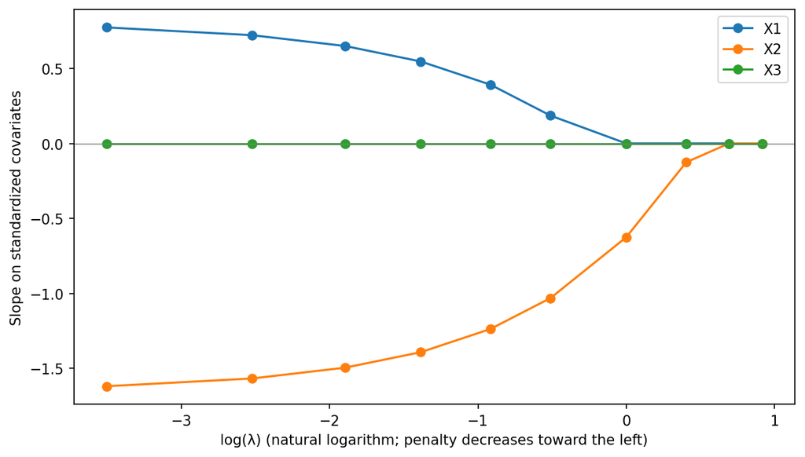

Coordinate-descent path on standardized covariates. Follow the plot from right to left as the penalty decreases.

As the penalty decreases, $X_2$ enters first (at 1.5 on the supplied grid), followed by $X_1$ (at 0.6). The third covariate never enters on this grid. This is consistent with the true absolute coefficients 2, 1, and 0, respectively. Entry is actually governed by empirical partial scores, so true coefficient magnitude alone does not guarantee this order in every random dataset.

### (c) Smallest penalty versus least squares

| Fit on standardized predictors | $b_1$ | $b_2$ | $b_3$ |
| --- | --- | --- | --- |
| Lasso, $\lambda=0.03$ | 0.773204 | -1.618324 | 0.000000 |
| Least squares | 0.806363 | -1.650248 | -0.012041 |

In this run, $X_3$ is still zero at the smallest requested penalty. Its nonzero least-squares estimate reflects finite-sample noise, not a population signal. The small positive penalty keeps the two strong slopes close to their OLS values while shrinking them toward zero and thresholding the weak third slope exactly to zero. They are not identical because $\lambda=0.03$ still imposes a penalty. For this full-rank design the lasso solution approaches OLS as $\lambda$ approaches zero; sufficiently smaller penalties would eventually allow the nonzero OLS coefficient for $X_3$ to emerge.

## Question 4: Diabetes prediction

### Training, validation, and penalty conventions

I matched the supplied `row_id` values to the data rows and used the provided **353 training observations**, **89 test observations**, and ten training fold labels. For each method, `GridSearchCV` evaluated the same 61 penalties `np.logspace(-4, 2, 61)` using `PredefinedSplit` and negative MSE scoring. I report positive MSE, averaged equally over the ten validation folds.

Each fit used a `Pipeline` with `StandardScaler` followed by the regression model. The scaler learned means and divisor-$n$ scales only from the current fitting observations. With `fit_intercept=True`, each estimator centers the response internally on those same fitting observations and fits an unpenalized intercept. Validation and test predictions use the fitted training transformations.

`Lasso`, `Ridge`, and `ElasticNet(l1_ratio=0.5)` select the three penalty families. The tabulated penalty is the scikit-learn `alpha` parameter. Lasso and elastic net use the normalized objectives given above, whereas `Ridge` minimizes $\|y-b_0-Zb\|_2^2+\texttt{alpha}\|b\|_2^2$. Consequently these numerical penalties are package parameters, not directly comparable measures of shrinkage across methods. I used the assignment’s specified Python grids without rescaling ridge’s parameter.

### Cross-validation results

| Method | Penalty | CV MSE | Fold SE |
| --- | --- | --- | --- |
| Lasso | 0.100000 | 3071.246869 | 240.352677 |
| Ridge | 0.501187 | 3073.485775 | 242.146754 |
| Elastic net | 0.003162 | 3073.448712 | 242.100086 |

The shading in each plot is plus or minus one standard error, calculated as the sample standard deviation of the ten fold MSEs divided by $\sqrt{10}$. This is a descriptive fold-variability summary, not an independence-based confidence interval. Selection uses the **minimum mean CV MSE**, not the one-standard-error rule.

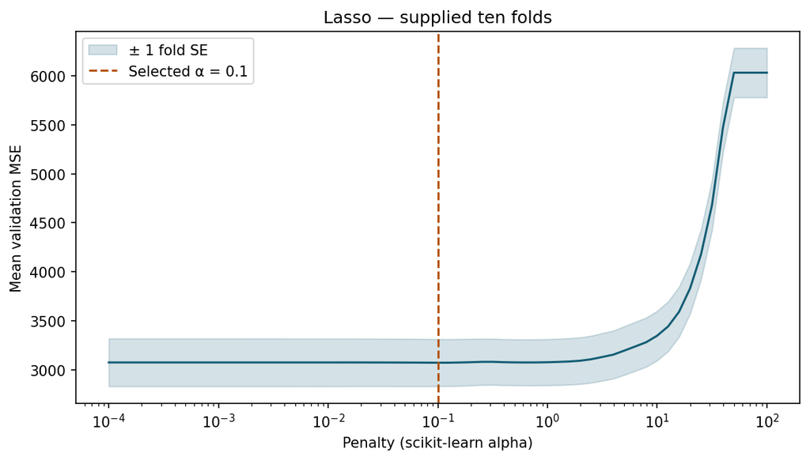

Lasso cross-validation curve.

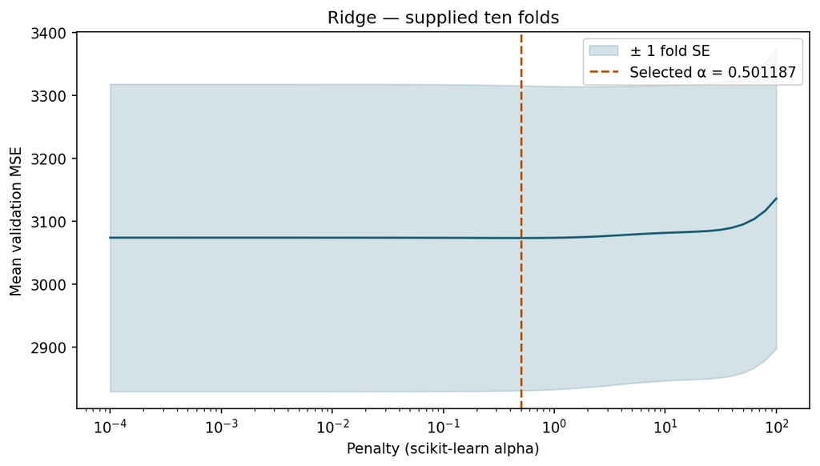

Ridge cross-validation curve.

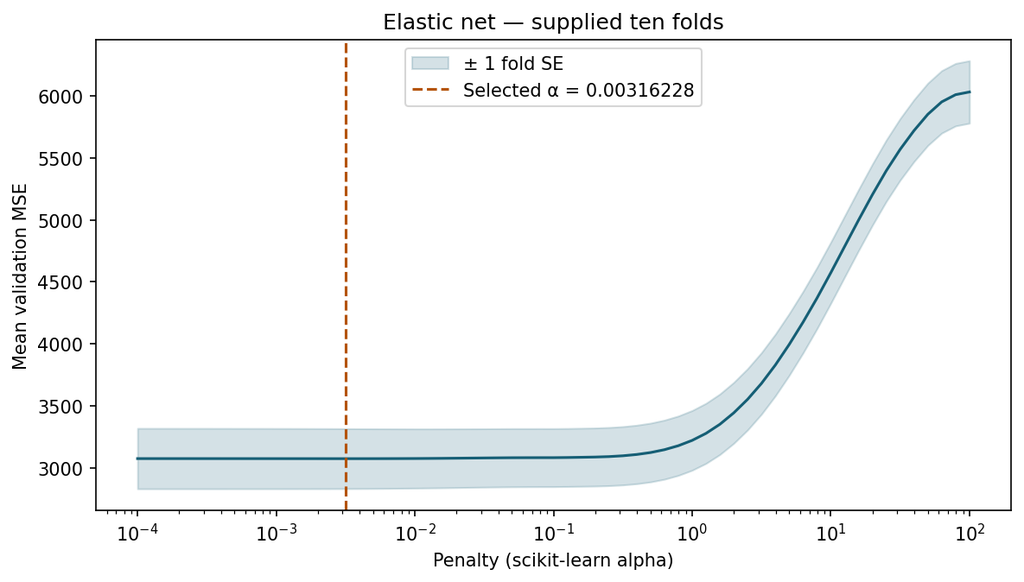

Elastic-net cross-validation curve.

**Lasso at penalty 0.1** has the smallest minimum CV MSE, **3071.247**, and is therefore the selected method. The other minima are only about 2.2 MSE units higher. This small numerical advantage determines the requested choice; it does not provide strong evidence that lasso would consistently outperform the alternatives.

### Final test assessment

After choosing lasso using training CV, I refitted its scaler and coefficients on all 353 training observations. I then evaluated this selected fit once on the 89 test observations:

$$\operatorname{MSE}_{\mathrm{test}}
=\frac1{89}\sum_{i\in\mathrm{test}}(y_i-\widehat y_i)^2
=\boxed{2732.4104}.$$

No test errors from the other methods were used to choose or revise the model. The test MSE being lower than CV MSE is compatible with variation in the held-out samples and fitting on a larger training sample in the final fit.

## Sources and reproducibility

- [Week 4 course page](https://teazrq.github.io/stat432rpy/week-04-lasso-and-variable-selection.html) and its homework ZIP: assignment and supplied diabetes data/folds.
- [scikit-learn ElasticNet documentation](https://scikit-learn.org/stable/modules/generated/sklearn.linear_model.ElasticNet.html): penalty and mixing-parameter conventions.
- [scikit-learn Ridge documentation](https://scikit-learn.org/stable/modules/generated/sklearn.linear_model.Ridge.html): ridge objective and intercept convention.

The course-provided `solutions-04.qmd` is retained as downloaded; the computations in this report come from `analysis-04.py`. Numerical runs use NumPy 2.2.2 and scikit-learn 1.9.1. Random-number generators differ across languages, so simulation numbers need not match the supplied R solution.

To reproduce from this directory, run:

```bash
python analysis-04.py
python build-report-04.py
quarto render homework-04.qmd
```

The `results/` directory contains slope arrays, summary CSVs, convergence checks, figures, CV fold errors, and final test predictions. The rendered HTML embeds its resources and is the submission artifact.

### Complete analysis code

```python
"""Reproduce Homework 04: python analysis-04.py (run from any directory)."""
from pathlib import Path
import json
import warnings
import numpy as np
import pandas as pd
import sklearn
import matplotlib
matplotlib.use('Agg')
import matplotlib.pyplot as plt
from sklearn.linear_model import Lasso, ElasticNet, Ridge
from sklearn.model_selection import GridSearchCV, PredefinedSplit
from sklearn.pipeline import Pipeline
from sklearn.preprocessing import StandardScaler
from sklearn.exceptions import ConvergenceWarning

ROOT = Path(__file__).resolve().parent
OUT = ROOT / 'results'
OUT.mkdir(exist_ok=True)
warnings.filterwarnings('error', category=ConvergenceWarning)
plt.rcParams.update({'figure.dpi': 150, 'font.size': 10})
penalties = np.array([.08, .12, .18, .24])
names = [f'X{j}' for j in range(1, 11)]
summary = {'numpy': np.__version__, 'sklearn': sklearn.__version__}

def savefig(name):
    plt.tight_layout()
    plt.savefig(OUT / f'{name}.png', bbox_inches='tight')
    plt.close()

# Reusing each generated dataset gives exact pairing of the two procedures.
rng = np.random.default_rng(43246)
coefs = {m: np.zeros((200, 10, 4)) for m in ['lasso', 'elastic_net']}
iterations = {m: [] for m in coefs}
gaps = {m: [] for m in coefs}
for rep in range(200):
    x1 = rng.standard_normal(120)
    z = rng.standard_normal(120)
    rest = rng.standard_normal((8, 120)).T
    x = np.column_stack([x1, .999*x1 + np.sqrt(1-.999**2)*z, rest])
    y = x @ np.array([.15,.15,.30,.15,0,0,0,0,0,0]) + rng.standard_normal(120)
    scale = x.std(axis=0, ddof=0)
    xs = (x-x.mean(axis=0))/scale
    yc = y-y.mean()
    for k, lam in enumerate(penalties):
        for method in coefs:
            cls = Lasso if method == 'lasso' else ElasticNet
            extra = {} if method == 'lasso' else {'l1_ratio': .5}
            model = cls(alpha=lam, fit_intercept=False, tol=1e-10,
                        max_iter=100000, selection='cyclic', **extra).fit(xs, yc)
            assert model.n_iter_ < 100000
            coefs[method][rep, :, k] = model.coef_/scale
            iterations[method].append(int(model.n_iter_))
            gaps[method].append(float(model.dual_gap_))

for method, b in coefs.items():
    np.save(OUT / f'{method}-slopes.npy', b)
    selected = np.abs(b) > 1e-8
    freq = selected.mean(axis=0)
    magnitude = np.abs(b).mean(axis=0)
    for label, values in [('frequency',freq), ('magnitude',magnitude)]:
        pd.DataFrame(values, index=names, columns=penalties).to_csv(OUT / f'{method}-{label}.csv')
        if method == 'elastic_net' and label == 'magnitude':
            continue
        plt.figure(figsize=(8,4.6))
        for k, lam in enumerate(penalties):
            plt.plot(names, values[:,k], 'o-', label=f'λ = {lam:.2f}')
        plt.xlabel('Covariate')
        plt.ylabel('Selection frequency' if label == 'frequency' else 'Mean absolute slope (original scale)')
        if label == 'frequency': plt.ylim(-.025,1.025)
        plt.title(('Lasso' if method == 'lasso' else 'Elastic net (mix = 0.5)') + ': 200 repetitions')
        plt.legend(ncol=2)
        savefig(f'{method}-{label}')
    first, second = selected[:,0,:], selected[:,1,:]
    pair = np.array([(first & ~second).mean(0), (~first & second).mean(0),
                     (first & second).mean(0), (~first & ~second).mean(0)]).T
    assert np.allclose(pair.sum(axis=1), 1)
    pd.DataFrame(pair, index=penalties, columns=['Only X1','Only X2','Both','Neither']).to_csv(OUT/f'{method}-pair.csv')
    summary[method] = {'fits':len(iterations[method]),'max_iterations':max(iterations[method]),
                       'max_dual_gap':max(gaps[method]), 'noise_frequency':freq[4:].mean(0).tolist()}

# A hand-written warm-start coordinate descent on standardized slopes.
rng = np.random.default_rng(43247)
x = rng.standard_normal((3,100)).T
y = 1.5 + x[:,0] - 2*x[:,1] + rng.standard_normal(100)
xs = (x-x.mean(0))/x.std(0,ddof=0)
yc = y-y.mean()
grid = np.array([2.5,2,1.5,1,.6,.4,.25,.15,.08,.03])
b = np.zeros(3)
rows = []
for lam in grid:
    for cycle in range(1,100001):
        old = b.copy()
        for j in range(3):
            residual_without_j = yc-xs@b+xs[:,j]*b[j]
            score = xs[:,j]@residual_without_j/100
            b[j] = np.sign(score)*max(abs(score)-lam,0)
        change = np.max(np.abs(b-old))
        if change < 1e-10:
            break
    else:
        raise RuntimeError('Coordinate descent failed to converge')
    score = xs.T@(yc-xs@b)/100
    active = np.abs(b)>1e-8
    violations = np.where(active, np.abs(score-lam*np.sign(b)), np.maximum(np.abs(score)-lam,0))
    reference = Lasso(alpha=lam,fit_intercept=False,tol=1e-12,max_iter=100000).fit(xs,yc)
    assert np.max(violations)<1e-8
    assert np.allclose(b,reference.coef_,atol=1e-8,rtol=0)
    rows.append([lam,*b,cycle,change,float(max(violations))])
path = pd.DataFrame(rows,columns=['lambda','X1','X2','X3','cycles','last_change','KKT_error'])
path.to_csv(OUT/'coordinate-path.csv',index=False)
lmax = float(np.max(np.abs(xs.T@yc/100)))
assert np.all(path.loc[path['lambda']>=lmax,names[:3]].to_numpy()==0)
ols = np.linalg.lstsq(xs,yc,rcond=None)[0]
summary['q3'] = {'lambda_max':lmax, 'intercept_standardized':float(y.mean()), 'ols':ols.tolist(),
                 'initial_scores':(xs.T@yc/100).tolist(),'max_KKT_error':float(path.KKT_error.max())}
plt.figure(figsize=(8,4.6))
for name in names[:3]: plt.plot(np.log(grid),path[name],'o-',label=name)
plt.axhline(0,color='gray',lw=.7)
plt.xlabel('log(λ) (natural logarithm; penalty decreases toward the left)')
plt.ylabel('Slope on standardized covariates')
plt.legend()
savefig('coordinate-path')

# Fixed folds, with preprocessing learned afresh in each training fold.
data = pd.read_csv(ROOT/'data/diabetes.csv')
split = pd.read_csv(ROOT/'data/diabetes-split-folds.csv')
assert np.array_equal(split.row_id,np.arange(1,len(data)+1))
train = split['split'].eq('train').to_numpy()
assert train.sum()==353 and (~train).sum()==89
folds = split.loc[train,'cv_fold'].astype(int).to_numpy()-1
assert set(folds)==set(range(10))
Xtrain = data.drop(columns='y').loc[train]
ytrain = data.loc[train,'y']
grid = np.logspace(-4,2,61)
models = {'Lasso':Lasso(tol=1e-10,max_iter=100000),
          'Ridge':Ridge(solver='svd'),
          'Elastic net':ElasticNet(l1_ratio=.5,tol=1e-10,max_iter=100000)}
tuned = {}
comparison = []
for method, model in models.items():
    # fit_intercept=True centers y using only the current fitting observations.
    pipe = Pipeline([('scale',StandardScaler()),('model',model)])
    search = GridSearchCV(pipe,{'model__alpha':grid},cv=PredefinedSplit(folds),
                          scoring='neg_mean_squared_error',refit=False,error_score='raise')
    search.fit(Xtrain,ytrain)
    means = -search.cv_results_['mean_test_score']
    fold_mse = -np.column_stack([search.cv_results_[f'split{i}_test_score'] for i in range(10)])
    se = fold_mse.std(axis=1,ddof=1)/np.sqrt(10)
    best = search.best_index_
    comparison.append([method,float(grid[best]),float(means[best]),float(se[best])])
    tuned[method] = pipe.set_params(**search.best_params_)
    slug = method.lower().replace(' ','-')
    pd.DataFrame({'alpha':grid,'mean_mse':means,'se':se}).to_csv(OUT/f'cv-{slug}.csv',index=False)
    np.save(OUT/f'cv-{slug}-fold-mse.npy',fold_mse)
    plt.figure(figsize=(8,4.6))
    plt.semilogx(grid,means,'-',color='#155e75')
    plt.fill_between(grid,means-se,means+se,alpha=.18,color='#155e75',label='± 1 fold SE')
    plt.axvline(grid[best],color='#b45309',ls='--',label=f'Selected α = {grid[best]:.6g}')
    plt.xlabel('Penalty (scikit-learn alpha)')
    plt.ylabel('Mean validation MSE')
    plt.title(method+' — supplied ten folds')
    plt.legend()
    savefig(f'cv-{slug}')
comparison = pd.DataFrame(comparison,columns=['Method','Penalty','CV MSE','Fold SE'])
comparison.to_csv(OUT/'cv-comparison.csv',index=False)
winner = comparison.loc[comparison['CV MSE'].idxmin(),'Method']
final = tuned[winner].fit(Xtrain,ytrain)
# Access test outcomes only after choosing the procedure using training CV.
pred = final.predict(data.drop(columns='y').loc[~train])
test_mse = float(np.mean((data.loc[~train,'y'].to_numpy()-pred)**2))
pd.DataFrame({'row_id':split.loc[~train,'row_id'],'observed':data.loc[~train,'y'],'predicted':pred}).to_csv(OUT/'final-test-predictions.csv',index=False)
summary['q4'] = {'method':winner,'penalty':float(final.named_steps['model'].alpha),'test_mse':test_mse}
(OUT/'summary.json').write_text(json.dumps(summary,indent=2)+'\n',encoding='utf-8')
print(json.dumps(summary,indent=2))
print(comparison.to_string(index=False))
print(path.to_string(index=False))
```